# Introduction to psfm

## Load Package

First let us load the sfa package.

```r
library(sfa)
```

## Which panel model? An overview of `psfm()`

`psfm()` is the panel-data entry point of the sfa package (`sfm()`, `zsfm()`, and `ttsfm()` are its cross-sectional counterparts – see their own help pages, `?sfm`/`?zsfm`/`?ttsfm`). It fits one of twenty-one `model_name` choices, selected via the `model_name` argument. The most commonly used are listed here; `?psfm` has the full list, including the classical panel estimators (`"CSS"`, `"LS"`, `"KSS"`, `"SSRE"`, `"SSCRE"`) added since this vignette was written:

| `model_name` | Individual effect | Estimator | Notes |
| --- | --- | --- | --- |
| `"TRE"` | random | simulated ML (Halton draws) | homoskedastic $\sigma_u$ |
| `"TRE_Z"` | random | simulated ML | $\sigma_u$ a function of covariates (1 pipe) |
| `"GTRE"` | random, persistent + transient | simulated ML | homoskedastic $\sigma_u$, $\sigma_h$ |
| `"GTRE_Z"` | random, persistent + transient | simulated ML | $\sigma_u$, $\sigma_h$ both covariate-driven (2 pipes) |
| `"TFE"` | fixed | ML (Chen, Schmidt & Wang 2014) | no separate noise-vs-effect random draw for $r_i$ |
| `"FD"` | random, persistent | first-differenced GLS (Wang & Ho 2010) | $\sigma_u$ time-invariant, scaled by covariates (1 pipe) |
| `"GTRE_SEQ1"`, `"GTRE_SEQ2"` | random | sequential moment-based | fast, but not maximum likelihood |
| `"SSFE"` | fixed | LSDV (Schmidt & Sickles 1984) | deterministic, no optimizer |
| `"PL80"` | random, persistent | ML, closed form | Pitt & Lee (1980) |
| `"BC92"` | random, time-varying | ML, closed form | Battese & Coelli (1992) |
| `"CSS"` | fixed, time-varying | firm-specific quadratic | Cornwell, Schmidt & Sickles (1990) |
| `"LS"` | fixed, common time path | rank-one factor, ALS | Lee & Schmidt (1993) |
| `"KSS"` | fixed, factor structure | factor model, rank chosen by IC | Kneip, Sickles & Song (2012) |
| `"SSRE"`, `"SSCRE"` | random / correlated random | GLS, Mundlak means for `SSCRE` | Schmidt & Sickles (1984) |

The last four assume no distribution for inefficiency at all – they identify it from the firm effects rather than from a one-sided likelihood – so they carry no `sigma_u` and report slopes only. They are the right comparison when you want to know how much of your efficiency ranking is coming from the half-normal assumption.

Every model shares the same `formula`/`data`/`individual` calling convention, so switching between them is usually just a change of `model_name` (and, for the `_Z`/`FD` models, adding the relevant formula pipe – see “Heteroskedastic inefficiency” below). This vignette walks through the most commonly used model, `GTRE`, in full, then shows the heteroskedastic (`GTRE_Z`) variant and the parametric bootstrap. See `?psfm` and each model’s own documentation (e.g. `?data_gen_p`, which lists every DGP column and which model it targets) for the rest.

## Generalized True Random Effects Model

We are interested in estimating the Generalized True Random Effects Model (GTRE) model of Filippini and Greene (2016) using simulated maximum likelihood. We will begin by using a simulated data set. We use the `data_gen_p` call to create a simulated data set. The `psfm` call runs the likelihood through three successive optimizer routines, only updating the parameter values if there is an improvement in the likelihood. We have opted for 150 iterations of the “bobyqa” procedure, 10 for “psoptim”, and 10 for “optim”. `rand` sets the seed (via `set.seed()`) for replication. Other arguments set the true $\sigma$’s and $\beta$’s used to generate the data, with `cons` for $\beta_0$/the constant. `rand.gtre` and `rand.psoptim` seed the simulated-ML Halton draws and the particle-swarm stage respectively; without them a model fit with `PSopt = TRUE` is not reproducible from one session to the next, which is why every fit below sets them.

Every fit in this vignette is deliberately sized to build quickly rather than to be a serious estimation exercise: a 70-firm, 6-period panel, only 50 Halton draws (`halton_num`), and a handful of optimizer iterations. Real work should use a genuine panel and the defaults – `halton_num` alone defaults to `ceiling(sqrt(nrow(data))) + 100`, several times what is used here. Expect the numbers below to move if you rerun them at a realistic size.

### Which estimator: `"fiml"` or `"sml"`

`model_name = "GTRE"` names the *model*; `estimator` chooses how it is fitted. Since 1.1.4 the default is `"fiml"`, full-information maximum likelihood through the model’s closed-skew-normal representation, which integrates the persistent block exactly and needs no draws at all. The fit below pins `estimator = "sml"` – simulated maximum likelihood over Halton draws – so that the `halton_num`/`rand.gtre` arguments have something to do.

Which to use:

- **`"fiml"`** is the default, is deterministic, and is several times faster. It requires a **balanced** panel; on an unbalanced one `psfm()` warns and falls back to `"sml"`.
- **`"sml"`** handles unbalanced panels, and on the evidence of the package’s own benchmarks returns better technical-efficiency *scores* (see `horserace/` in the development repository). It is the slower route.

One consequence worth knowing: `psfm(model_name = "GTRE")` returns an object whose `$model_name` is `"GTRE_FML"` under the default. That is the name to use when you look it up in tables like the one above.

```r
data_trial <- data_gen_p(t=6, N=70, rand = 16, sig_u = 0.3, sig_v = 0.1, sig_r = 0.1, sig_h = 0.3, cons = 0.5, beta1 = 0.5, beta2 = 0.5)

p.gtre_sml   <- psfm(formula      = y_gtre ~ x1 + x2,
                     model_name   = "GTRE",
                     estimator    = "sml",
                     data         = data_trial,
                     individual   = "name",
                     PSopt        = TRUE,
                     optHessian   = TRUE,
                     halton_num   = 50,
                     rand.gtre    = 1,
                     rand.psoptim = 1,
                     maxit.bobyqa = 150,
                     maxit.psoptim= 10,
                     maxit.optim  = 10)
```

```
#> Warning in commonArgs(par, fn, control, environment()): maxfun < 10 *
#> length(par)^2 is not recommended.
```

```r
summary(p.gtre_sml)
```

```
#> --- SFA Regression Model Summary ---
#> Formula: y_gtre ~ x1 + x2
#> Total time: 7.608213
#> Model Output:
#>                   par     st_err     t-val
#> lambda      2.8394395 0.63905659  4.443174
#> sigma       0.3045838 0.01828817 16.654688
#> sigr        0.0887480 0.03505840  2.531434
#> sigh        0.3707308 0.03483123 10.643631
#> (Intercept) 0.5060797 0.05436173  9.309485
#> x1          0.5009620 0.01028763 48.695554
#> x2          0.4979087 0.01265119 39.356655
#> log likelihood: 16.61189
#> convergence: 1 -- ITERATION LIMIT REACHED; this is not a converged optimum
#>   optimizer message: NEW_X
#>   a non-zero code does not by itself mean the fit failed --
#>   run sfa_diagnostics() on this fit to see the gradient and Hessian.
```

```r
mean(p.gtre_sml$U)
```

```
#> [1] 0.8079776
```

```r
mean(p.gtre_sml$H)
```

```
#> [1] 0.7692999
```

## GTRE Results

We may be interested in plotting the densities of these efficiency scores:

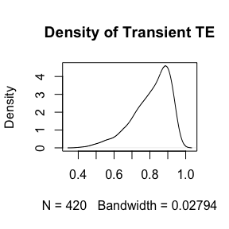

```r
plot(density(p.gtre_sml$U),main="Density of Transient TE")
```

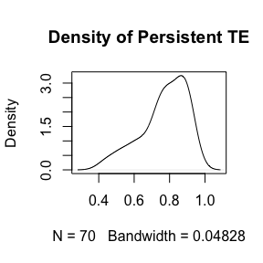

```r
plot(density(p.gtre_sml$H),main="Density of Persistent TE")
```

To get the total technical efficiency, we would simply multiply the TE’s of U and H in the following way:

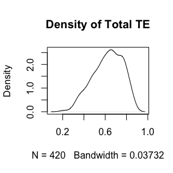

```r
total_te <- rep(p.gtre_sml$H, each=6) * p.gtre_sml$U
plot(density(total_te),main="Density of Total TE")
```

NB: Using the constant 6 in rep(p.gtre_sml$H, each=6) only works for a balanced panel with t=6 for each individual. For an unbalanced panel, the each argument in rep would not work. Instead, use the times argument and a vector of length N (number of individuals), with each of the time period lengths, e.g. rep(c(2,5),times=c(5,2)).